# Script to work with S2 bands derived from GEE

Read and manipulation data, calculate indices

Alicia Valdés

16 marzo 2026

# Load libraries

```r
library(signal)
library(tidyverse)
library(here)
library(lubridate)
library(dtplyr)
library(sf)
library(knitr)
library(mgcv)
library(future)
library(furrr)
library(progressr)
library(pracma)
```

# Load functions

```r
knitr::purl("functions_20260225.Rmd", output = "functions_20260225.R")
```

```
[1] "functions_20260225.R"
```

```r
source("functions_20260225.R")
```

# Supress package messages

```r
suppressPackageStartupMessages({
  library(mgcv)
  library(nlme)
})
```

# Load previously created objects

```r
load(file = "objects/data_RS_S2_bands_indices.Rdata")
load(file = "objects/GAM_data_S2.Rdata")
load(file = "objects/smoothed_data_S2.Rdata")
load(file = "objects/monthly_avg_indices_S2.Rdata")
```

# Load Resurvey db

```r
ReSurvey_data <- read_csv(
  here("data", "clean", "ReSurvey_QRST_data_V2025.2_20260304.csv")) %>%
  select(PlotObservationID, EUNIS1, EUNIS2) %>%
  mutate(PlotObservationID = factor(PlotObservationID),
         EUNIS1 = factor(EUNIS1), EUNIS2 = factor(EUNIS2))
```

# Read files with band data

I got these files using the GEE code prepared by Bea.

These files contain all observations in the ReSurvey database from 2016 onward. In order to avoid computation problems in GEE, biogeographical units that contain more than 4500 points have been subdivided in ArcGIS. Now I also divided files by years

```r
# Set the folder path
folder_path <- "C:/Data/MOTIVATE/MOTIVATE_RS_data/validation/S2/Years"

# List CSV files
csv_files <- list.files(folder_path, full.names = TRUE, recursive = TRUE)

# Read one file to get column names
sample_file <- csv_files[1]
sample_data <- read_csv(sample_file, n_max = 0)

# Read and process each file
data_list <- lapply(csv_files, function(file) {
  info <- extract_info(basename(file)) # Use only the filename

  # Read the file
  df <- read_csv(file) %>%
    mutate(biogeo = info$biogeo, unit = info$unit)

  return(df)
  })

# Combine all data
data_RS_S2_bands <- bind_rows(data_list)

# View the resulting tibble
print(data_RS_S2_bands)
```

```
# A tibble: 1,826,496 × 16
   `system:index`                       B11    B2    B3    B4    B8 PltObID UNIT  date       image_id time_utc timestamp  year .geo  biogeo unit
   <chr>                              <dbl> <dbl> <dbl> <dbl> <dbl>   <dbl> <chr> <date>     <chr>    <time>       <dbl> <dbl> <chr> <chr>  <chr>
 1 20161228T102432_20161228T102428_T…   238  6291  5136  4013  2968    4120 ALPA… 2016-12-28 2016122… 10:27      1.48e12  2016 "{\"… ALP    ALPS
 2 20161228T102432_20161228T102428_T…   235  6499  5267  4290  3231    4121 ALPA… 2016-12-28 2016122… 10:27      1.48e12  2016 "{\"… ALP    ALPS
 3 20161228T102432_20161228T102428_T…   234  6653  5508  4326  3471    4122 ALPA… 2016-12-28 2016122… 10:27      1.48e12  2016 "{\"… ALP    ALPS
 4 20161228T102432_20161228T102428_T…   307  6985  6060  5263  4353    4123 ALPA… 2016-12-28 2016122… 10:27      1.48e12  2016 "{\"… ALP    ALPS
 5 20161228T102432_20161228T102428_T…   392  7232  6331  5443  4600    4124 ALPA… 2016-12-28 2016122… 10:27      1.48e12  2016 "{\"… ALP    ALPS
 6 20161228T102432_20161228T102428_T…   392  7170  6351  5439  4764    4125 ALPA… 2016-12-28 2016122… 10:27      1.48e12  2016 "{\"… ALP    ALPS
 7 20161228T102432_20161228T102428_T…   353  7304  6111  5324  4360    4126 ALPA… 2016-12-28 2016122… 10:27      1.48e12  2016 "{\"… ALP    ALPS
 8 20161228T102432_20161228T102428_T…   353  7117  6171  5415  4272    4127 ALPA… 2016-12-28 2016122… 10:27      1.48e12  2016 "{\"… ALP    ALPS
 9 20161228T102432_20161228T102428_T…   306  7147  6242  5111  4396    4128 ALPA… 2016-12-28 2016122… 10:27      1.48e12  2016 "{\"… ALP    ALPS
10 20161228T102432_20161228T102428_T…   373  6743  5691  4705  3918    4129 ALPA… 2016-12-28 2016122… 10:27      1.48e12  2016 "{\"… ALP    ALPS
# ℹ 1,826,486 more rows
# ℹ Use `print(n = ...)` to see more rows
```

```r
# Counts per biogeo and unit
print(data_RS_S2_bands %>% count(biogeo, unit), n = 100)
```

```
# A tibble: 17 × 3
   biogeo  unit         n
   <chr>   <chr>    <int>
 1 ALP     ALPS    156061
 2 ALP     ATRA      8927
 3 ALP     PYR         77
 4 ATL     BENELUX 329640
 5 ATL     BRITAIN 121973
 6 ATL     IBERIA    1423
 7 CON     AUSTRIA 134992
 8 CON     BALKAN     269
 9 CON     FRANCE   73386
10 CON     GERMANY  65358
11 CON     ITALICA   7707
12 CON     NORDIC  770510
13 CON     POLAND   84072
14 MED     IBERIA    7182
15 MED     ITALICA  12548
16 MED     TIRRENO   3838
17 PANONIA NA       48533
```

# Remove unneded cols and rename

```r
data_RS_S2_bands <- data_RS_S2_bands %>%
  select(-UNIT) %>%
  rename(PlotObservationID = PltObID)
```

# Read file with band data for points outside polygons

Some points from the ReSurvey database fall outside the bioregion polygons. These points were manually assigned to the closest biogeo and unit in ArcGIS (those far out were assigned biogeo = OUT and unit = OUT). Data for these points has been extracted with a different GEE script.

```r
data_RS_S2_bands_out <- read_csv(
  "C:/Data/MOTIVATE/MOTIVATE_RS_data/validation/S2_out/AllPoints_S2_Annual.csv") %>%
  rename(biogeo = BIOGEO, unit = UNIT,
         PlotObservationID = PltObID) %>%
  select(`system:index`, B11, B2, B3, B4, B8, PlotObservationID, date, image_id,
         time_utc ,timestamp, year, .geo, biogeo, unit)
```

Change unit names:

```r
data_RS_S2_bands_out <- data_RS_S2_bands_out %>%
  mutate(unit = case_when(
    unit == "ALPALPS" ~ "ALPS",
    unit == "ATLBENELUX" ~ "BENELUX",
    unit == "ATLBRITAIN" ~ "BRITAIN",
    unit == "CONAUSTRIA" ~ "AUSTRIA",
    unit == "CONGERMANY" ~ "GERMANY",
    unit == "CONITALICA" ~ "ITALICA",
    unit == "CONNORDIC" ~ "NORDIC",
    unit == "MEDITALICA" ~ "ITALICA",
    TRUE ~ unit
  ))
```

Check that column names are the same:

```r
# Columns in data_RS_S2_bands but not in data_RS_S2_bands_out
setdiff(names(data_RS_S2_bands), names(data_RS_S2_bands_out))
```

```
character(0)
```

```r
# Columns in data_RS_S2_bands_out but not in data_RS_S2_bands
setdiff(names(data_RS_S2_bands_out), names(data_RS_S2_bands))
```

```
character(0)
```

# Join all data

```r
data_RS_S2_bands <- bind_rows(data_RS_S2_bands, data_RS_S2_bands_out)
```

# Some checks

Check that the year in the date of the images is not different to the sampling year:

```r
data_RS_S2_bands %>% dplyr::filter(year != year(date))
```

| system:index | B11 | B2 | B3 | B4 | B8 | PlotObservationID | date | image_id | time_utc | timestamp | year | .geo | biogeo | unit |
| --- | --- | --- | --- | --- | --- | --- | --- | --- | --- | --- | --- | --- | --- | --- |

Check how many different images are for each observation, date and time:

```r
data_RS_S2_bands %>% group_by(PlotObservationID, date, time_utc) %>%
  summarise(n_images = n_distinct(image_id), .groups = "drop") %>%
  count(n_images)
```

| n_images | n |
| --- | --- |
| 1 | 1269615 |
| 2 | 247062 |
| 3 | 7254 |
| 4 | 16748 |
| 5 | 230 |
| 7 | 1 |
| 8 | 35 |

# Average the bands

When there is more than one image for each point and day, average the values of the bands:

# Calculate indices

Save:

Plot n_daytime:

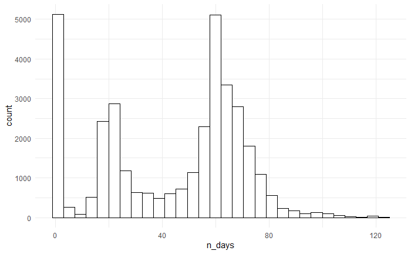

```r
data_RS_S2_bands_indices %>%
  group_by(PlotObservationID) %>%
  summarise(n_days = first(n_days)) %>% ungroup() %>%
  ggplot(aes(x = n_days)) + geom_histogram(color = "black", fill = "white") +
  theme_minimal()
```

# Compute phenological metrics from models fitted to time series data

## Calculation

Apply the function with batch processing

```r
plan(sequential)
```

## Save

Look:

```r
GAM_data
```

| PlotObservationID | index | sos_slope | pos | eos_slope | auc_slope | DOY | value |
| --- | --- | --- | --- | --- | --- | --- | --- |
| 4120 | NDVI | NA | NA | NA | NA | 363 | NA |
| 4120 | EVI | NA | NA | NA | NA | 363 | NA |
| 4120 | SAVI | NA | NA | NA | NA | 363 | NA |
| 4121 | NDVI | NA | NA | NA | NA | 363 | NA |
| 4121 | EVI | NA | NA | NA | NA | 363 | NA |
| 4121 | SAVI | NA | NA | NA | NA | 363 | NA |
| 4122 | NDVI | NA | NA | NA | NA | 363 | NA |
| 4122 | EVI | NA | NA | NA | NA | 363 | NA |
| 4122 | SAVI | NA | NA | NA | NA | 363 | NA |
| 4123 | NDVI | NA | NA | NA | NA | 363 | NA |

[output cut: 990 more lines]

Save as an object:

Add year to GAM_data:

```r
GAM_data <- GAM_data %>%
  left_join(data_RS_S2_bands_indices %>%
              select(PlotObservationID, year) %>%
              distinct(),
            by = "PlotObservationID")
```

## Extract average values of indices per month

Extract average values of indices per month and AUC between March and October;

Save as an object:

## Assess time series quality

For the time series to be acceptable, it should have a reasonable number of time points, and these points should be distributed along almost all months (could be ok to miss the winter months).

In GAM data, check how many time points are there for each PlotObservationID, how many months, and which months are missing.

```r
ts_quality <- GAM_data %>%
  # Filter only NDVI (all indices will have the same time points)
  dplyr::filter(index == "NDVI") %>%
  # Get month from DOY
  mutate(month = month(ymd("2020-01-01") + days(DOY - 1))) %>%
  # For each PlotObservationID
  group_by(PlotObservationID) %>%
  # Get the number of time points (days) and the number of months
  summarise(
    n_days = n_distinct(DOY),
    n_months = n_distinct(month),
    .groups = "drop"
  ) %>%
  left_join(GAM_data %>%
              # Filter only NDVI
              dplyr::filter(index == "NDVI") %>%
              # Get month from DOY
              mutate(month = month(ymd("2020-01-01") + days(DOY - 1))) %>%
              # Get unique values of PlotObservationID and month
              distinct(PlotObservationID, month) %>%
              # Add 1 as value
              mutate(value = 1) %>%
              # Reshape to wide format and add zeros when month is missing
              pivot_wider(
                names_from = month,
                names_prefix = "month",
                values_from = value,
                values_fill = 0),
            by = "PlotObservationID")
```

Histograms time points and n months:

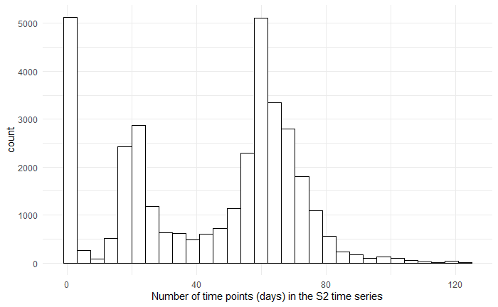

```r
ggplot(ts_quality, aes(x = n_days)) +
  geom_histogram(color = "black", fill = "white") +
  xlab("Number of time points (days) in the S2 time series") +
  theme_minimal()
```

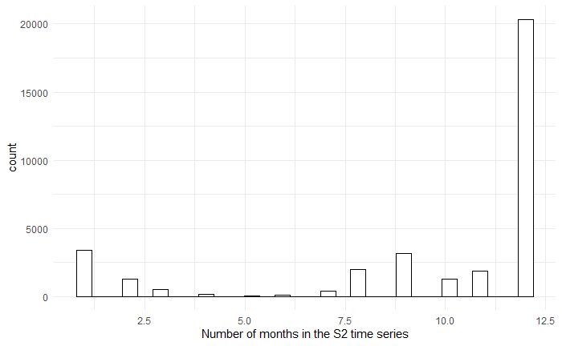

```r
ggplot(ts_quality, aes(x = n_months)) +
  geom_histogram(color = "black", fill = "white") +
  xlab("Number of months in the S2 time series") +
  theme_minimal()
```

Count how many PlotObservationIDs have missing data (value 0) for each month:

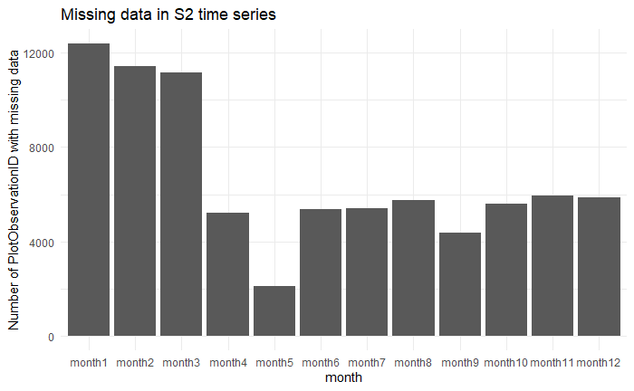

```r
obs_missing_month <- ts_quality %>%
  summarise(across(starts_with("month"), ~ sum(.x == 0))) %>%
  pivot_longer(cols = everything(), names_to = "month", values_to = "nobs_missing")

ggplot(obs_missing_month %>%
         mutate(month = factor(month, levels = paste0("month", 1:12))),
       aes(x = month, y = nobs_missing)) + geom_bar(stat = "identity") +
  ylab("Number of PlotObservationID with missing data") +
  ggtitle("Missing data in S2 time series") +
  theme_minimal()
```

Add quality flag:

```r
ts_quality_flag <- ts_quality %>%
  rowwise() %>%
  mutate(
    #  If 2 consecutive months of the period March-October are missing
    # quality_flag = 0
    quality_flag = {
      months <- c_across(month3:month10)
      if (any(months[-length(months)] == 0 & months[-1] == 0)) 0 else 1
    }
  ) %>%
  ungroup()
```

```r
ts_quality_flag %>% count(quality_flag)
```

| quality_flag | n |
| --- | --- |
| 0 | 6267 |
| 1 | 28244 |

## Boxplot comparing moments for different indices

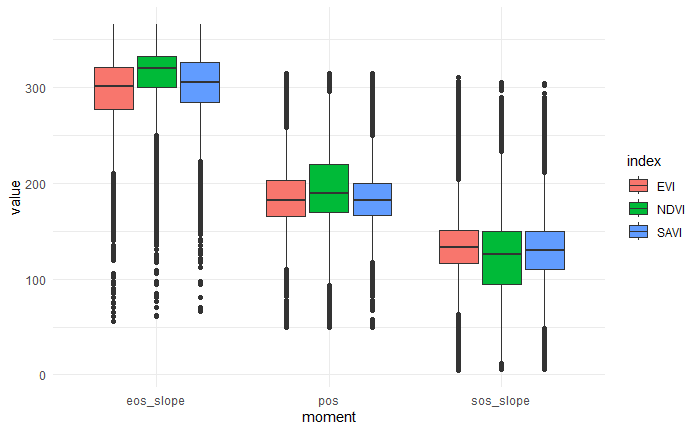

```r
GAM_data %>%
  select(PlotObservationID, index, sos_slope, pos, eos_slope) %>% distinct() %>%
  pivot_longer(cols = c(sos_slope, pos, eos_slope),
               names_to = "moment", values_to = "value") %>%
  ggplot(aes(x = moment, y = value, fill = index)) + geom_boxplot() +
  theme_minimal()
```

## TBD if needed: Plot fit and moments for each PlotObservationID

### Quality = 1

```r
# Get unique IDs with quality_flag == 1
ids_q1 <- ts_quality_flag %>%
  dplyr::filter(quality_flag == 1) %>%
  mutate(PlotObservationID = droplevels(PlotObservationID)) %>%
  pull(PlotObservationID)
GAM_data_ids_q1 <- GAM_data %>%
  # Join to get biogeo and unit
  left_join(data_RS_S2_bands_indices %>%
              select(PlotObservationID, biogeo, unit) %>%
              distinct()) %>%
  # Join to get EUNIS info
   left_join(ReSurvey_data %>%
               select(PlotObservationID, EUNIS1, EUNIS2)) %>%
  # Join to get original values of indices
  left_join(data_RS_S2_bands_indices %>%
              select(PlotObservationID, DOY, NDVI, EVI, SAVI) %>%
              pivot_longer(cols = c(NDVI, EVI, SAVI), names_to = "index",
                           values_to = "value_orig")) %>%
  # Join to get ts_quality data
  left_join(ts_quality_flag %>% select(PlotObservationID, quality_flag)) %>%
  # Keep only those with quality_flag == 1
  dplyr::filter(quality_flag == 1)
```

Save each plot to a file:

### Quality = 0

```r
# Get unique IDs with quality_flag == 0
ids_q0 <- ts_quality_flag %>%
  dplyr::filter(quality_flag == 0) %>%
  mutate(PlotObservationID = droplevels(PlotObservationID)) %>%
  pull(PlotObservationID)
GAM_data_ids_q0 <- GAM_data %>%
  # Join to get biogeo and unit
  left_join(data_RS_S2_bands_indices %>%
              select(PlotObservationID, biogeo, unit) %>%
              distinct()) %>%
  # Join to get EUNIS info
   left_join(ReSurvey_data %>%
               select(PlotObservationID, EUNIS1,EUNIS2)) %>%
  # Join to get original values of indices
  left_join(data_RS_S2_bands_indices %>%
              select(PlotObservationID, DOY, NDVI, EVI, SAVI) %>%
              pivot_longer(cols = c(NDVI, EVI, SAVI), names_to = "index",
                           values_to = "value_orig")) %>%
  # Join to get ts_quality data
  left_join(ts_quality_flag %>%
              select(PlotObservationID, n_months, quality_flag)) %>%
  # Keep only those with quality_flag == 0
  dplyr::filter(quality_flag == 0)
```

Save each plot to a file:

# Smooth the time series of NDMI and NDWI

## Calculation

Apply the function with batch processing.

```r
plan(sequential)
```

## Save

Look:

```r
smoothed_data
```

| PlotObservationID | DOY | index | value |
| --- | --- | --- | --- |
| 43441 | 47 | NDMI | 0.8671223190 |
| 43441 | 87 | NDMI | 0.6359513538 |
| 43441 | 99 | NDMI | 0.5581430350 |
| 43441 | 114 | NDMI | 0.4512013161 |
| 43441 | 137 | NDMI | 0.2729251945 |
| 43441 | 147 | NDMI | 0.1982936468 |
| 43441 | 154 | NDMI | 0.1504669856 |
| 43441 | 164 | NDMI | 0.0916302171 |
| 43441 | 177 | NDMI | 0.0355116584 |
| 43441 | 187 | NDMI | 0.0088553784 |

[output cut: 990 more lines]

Save as an object:

## TBD if needed: Plot fit and moments for each PlotObservationID

```r
smoothed_data_ids <- smoothed_data %>%
  # Join to get biogeo and unit
  left_join(data_RS_S2_bands_indices %>%
              select(PlotObservationID, biogeo, unit) %>%
              distinct()) %>%
  # Join to get EUNIS info
   left_join(ReSurvey_data %>%
               select(PlotObservationID, EUNIS1, EUNIS2)) %>%
  mutate(PlotObservationID = as.character(PlotObservationID))
```

Save each plot to a file:

# Get indices data (max. and min.)

These maximum and minimum values are from the smoothed time series. For values in DOY 1–50 and DOY 315–end, the GAM smoothing function replaced the original values with the mean base value of observations during each of these respective periods (this has now been done for all indices, i.e. NDVI, EVI, SAVI, NDMI and NDWI).

```r
final_indices_data <- GAM_data %>%
  group_by(PlotObservationID, index) %>%
  summarise(max = max(value), min = min(value)) %>%
  ungroup() %>%
  pivot_wider(names_from = index, values_from = c(max, min),
              names_glue = "{index}_{.value}") %>%
  full_join(
    smoothed_data %>%
      group_by(PlotObservationID, index) %>%
      summarise(max = max(value), min = min(value)) %>%
      ungroup() %>%
      pivot_wider(names_from = index, values_from = c(max, min),
                  names_glue = "{index}_{.value}")
    )
```

# Get phenology data

Use GAM iter_3 to get dates of the moments, values at those moments and AUC (time-integrated indices) between SOS and EOS:

```r
# Join to get values at SOS, POS, EOS and auc
final_phenology_data <- GAM_data %>%
  mutate(
    stage = case_when(
      DOY == sos_slope ~ "sos",
      DOY == pos ~ "pos",
      DOY == eos_slope ~ "eos",
      TRUE ~ NA_character_
    )
  ) %>%
  dplyr::filter(!is.na(stage)) %>%
  select(PlotObservationID, index, stage, doy = DOY, value) %>%
  pivot_wider(
    names_from = c(index, stage),
    values_from = c(doy, value),
    names_glue = "{index}_{stage}_{.value}"
  ) %>%
  # Convert list cols to regular numeric cols
  mutate(
    NDVI_sos_value = map_dbl(NDVI_sos_value, 1),
    NDVI_pos_value = map_dbl(NDVI_pos_value, 1),
    NDVI_eos_value = map_dbl(NDVI_eos_value, 1),
    EVI_sos_value = map_dbl(EVI_sos_value, 1),
    EVI_pos_value = map_dbl(EVI_pos_value, 1),
    EVI_eos_value = map_dbl(EVI_eos_value, 1),
    SAVI_sos_value = map_dbl(SAVI_sos_value, 1),
    SAVI_pos_value = map_dbl(SAVI_pos_value, 1),
    SAVI_eos_value = map_dbl(SAVI_eos_value, 1)
  ) %>%
  full_join(GAM_data %>%
              distinct(PlotObservationID, index, auc_slope) %>%
              rename(auc = auc_slope) %>%
              pivot_wider(names_from = index, values_from = c(auc),
                          names_glue = "{index}_{.value}"))
```

# Get values at POS-2 and POS+2

Alternative to use SOS/EOS or March/October: Use values at POS - 2 months and POS + 2 months.

```r
pos_pm60_df <- get_pos_minus_plus60(GAM_data, extrapolate = TRUE)
```

[output not shown]

# Join indices and phenology data

```r
final_RS_data <- full_join(
  # Indices data (max and min)
  final_indices_data,
  # Average values of indices per month
  monthly_avg_indices %>%
    pivot_wider(names_from = index, values_from = c(avg_value_01:auc_mar_oct),
                names_glue = "{index}_{.value}")
  ) %>%
  full_join(
    # Phenology data
    final_phenology_data
    ) %>%
   full_join(
     # Values at POS - 60 days and POS + 60 dAYS
     pos_pm60_df %>%
       select(-year, -pos, -target_doy_minus60, - target_doy_plus60) %>%
       pivot_wider(names_from = index,
                   values_from = c(pos_minus60_value, pos_plus60_value, auc_pos2),
                   names_glue = "{index}_{.value}")
   ) %>%
  # Sort cols in alphabetical order
  select(PlotObservationID, sort(names(.)[names(.) != "PlotObservationID"]))
```

# Add EUNIS codes

```r
final_RS_data <- final_RS_data %>% left_join(ReSurvey_data)
```

```r
data_RS_S2_bands_indices <- data_RS_S2_bands_indices %>%
  left_join(ReSurvey_data)
```

# Monthly spectrophenology per habitat type

```r
# Prepare the data
data_monthly_EUNIS1 <- data_RS_S2_bands_indices %>%
  mutate(month = month(date, label = TRUE, abbr = TRUE, locale="EN-us")) %>%
  group_by(month, EUNIS1) %>%
  summarise(
    mean_NDVI = mean(NDVI, na.rm = TRUE),
    sd_NDVI = sd(NDVI, na.rm = TRUE),
    n_NDVI = sum(!is.na(NDVI)),
    mean_EVI = mean(EVI, na.rm = TRUE),
    sd_EVI = sd(EVI, na.rm = TRUE),
    n_EVI = sum(!is.na(EVI)),
    mean_SAVI = mean(SAVI, na.rm = TRUE),
    sd_SAVI = sd(SAVI, na.rm = TRUE),
    n_SAVI = sum(!is.na(SAVI)),
    .groups = "drop"
  )

data_monthly_EUNIS1 <- data_monthly_EUNIS1 %>%
  # Add label with n
  left_join(data_monthly_EUNIS1 %>%
              group_by(EUNIS1) %>%
              summarise(n_total = sum(n_NDVI, na.rm = TRUE)),
            by = "EUNIS1") %>%
  mutate(EUNIS1_label = paste0(EUNIS1, " (n = ", n_total, ")"))

data_monthly_EUNIS2 <- data_RS_S2_bands_indices %>%
  mutate(month = month(date, label = TRUE, abbr = TRUE, locale="EN-us")) %>%
  group_by(month, EUNIS1, EUNIS2) %>%
  summarise(
    mean_NDVI = mean(NDVI, na.rm = TRUE),
    sd_NDVI = sd(NDVI, na.rm = TRUE),
    n_NDVI = sum(!is.na(NDVI)),
    mean_EVI = mean(EVI, na.rm = TRUE),
    sd_EVI = sd(EVI, na.rm = TRUE),
    n_EVI = sum(!is.na(EVI)),
    mean_SAVI = mean(SAVI, na.rm = TRUE),
    sd_SAVI = sd(SAVI, na.rm = TRUE),
    n_SAVI = sum(!is.na(SAVI)),
    .groups = "drop"
  )

data_monthly_EUNIS2 <- data_monthly_EUNIS2 %>%
  # Add label with n
  left_join(data_monthly_EUNIS2 %>%
              group_by(EUNIS2) %>%
              summarise(n_total = sum(n_NDVI, na.rm = TRUE)),
            by = "EUNIS2") %>%
  mutate(EUNIS2_label = paste0(EUNIS2, " (n = ", n_total, ")"))
```

## EUNIS level 1

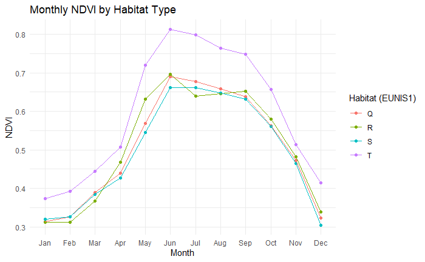

```r
# Plots

# EUNIS1
ggplot(data_monthly_EUNIS1,
       aes(x = month, y = mean_NDVI, color = EUNIS1,
           group = EUNIS1)) +
  geom_point() +
  geom_line(aes(group = EUNIS1)) +
  #geom(aes(ymin = mean_NDVI - sd_NDVI, ymax = mean_NDVI + sd_NDVI),
  #width = 0.2) +
  labs(
    title = "Monthly NDVI by Habitat Type",
    x = "Month",
    y = "NDVI",
    color = "Habitat (EUNIS1)"
  ) +
  theme_minimal()
ggsave(
  here("output", "figures", "monthly_spectrophenology_S2", "EUNIS1_NDVI.jpeg"),
  dpi = 300, width = 6, height = 2.5)
```

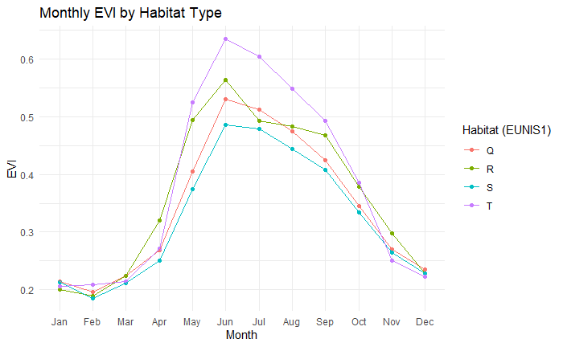

```r
ggplot(data_monthly_EUNIS1,
       aes(x = month, y = mean_EVI, color = EUNIS1,
           group = EUNIS1)) +
  geom_point() +
  geom_line() +
  #geom(aes(ymin = mean_EVI - sd_EVI, ymax = mean_EVI + sd_EVI),
                #width = 0.2) +
  labs(
    title = "Monthly EVI by Habitat Type",
    x = "Month",
    y = "EVI",
    color = "Habitat (EUNIS1)"
  ) +
  theme_minimal()
ggsave(
  here("output", "figures", "monthly_spectrophenology_S2", "EUNIS1_EVI.jpeg"),
  dpi = 300, width = 6, height = 2.5)
```

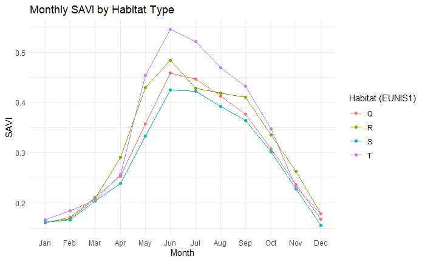

```r
ggplot(data_monthly_EUNIS1,
       aes(x = month, y = mean_SAVI, color = EUNIS1,
           group = EUNIS1)) +
  geom_point() +
  geom_line() +
  #geom(aes(ymin = mean_SAVI - sd_SAVI, ymax = mean_SAVI + sd_SAVI),
                #width = 0.2) +
  labs(
    title = "Monthly SAVI by Habitat Type",
    x = "Month",
    y = "SAVI",
    color = "Habitat (EUNIS1)"
  ) +
  theme_minimal()
ggsave(
  here("output", "figures", "monthly_spectrophenology_S2", "EUNIS1_SAVI.jpeg"),
  dpi = 300, width = 6, height = 2.5)
```

## EUNIS level 2

### Q

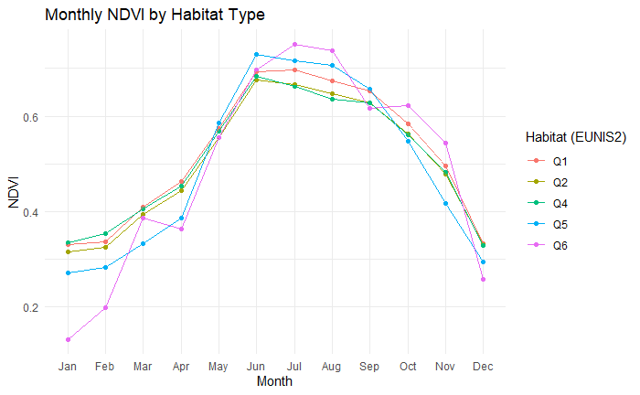

```r
# NDVI
ggplot(data_monthly_EUNIS2 %>%
         dplyr::filter(EUNIS1 == "Q" & !is.na(EUNIS2)) %>%
         # Remove those with EUNIS level 2 that does not match current classif
         dplyr::filter(EUNIS2 != "Qa" & EUNIS2 != "Qb"),
       aes(x = month, y = mean_NDVI, color = EUNIS2, group = EUNIS2)) +
  geom_point() +
  geom_line() +
  #geom(aes(ymin = mean_NDVI - sd_NDVI, ymax = mean_NDVI + sd_NDVI),
                #width = 0.2) +
  labs(
    title = "Monthly NDVI by Habitat Type",
    x = "Month",
    y = "NDVI",
    color = "Habitat (EUNIS2)"
  ) +
  theme_minimal()
ggsave(
  here("output", "figures", "monthly_spectrophenology_S2", "EUNIS2_Q_NDVI.jpeg"),
  dpi = 300, width = 7, height = 2.5)
```

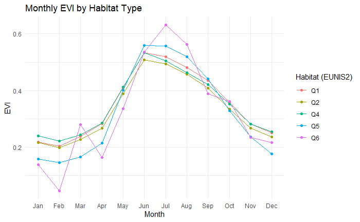

```r
# EVI
ggplot(data_monthly_EUNIS2 %>%
         dplyr::filter(EUNIS1 == "Q" & !is.na(EUNIS2)) %>%
         # Remove those with EUNIS level 2 that does not match current classif
         dplyr::filter(EUNIS2 != "Qa" & EUNIS2 != "Qb"),
       aes(x = month, y = mean_EVI, color = EUNIS2, group = EUNIS2)) +
  geom_point() +
  geom_line() +
  #geom(aes(ymin = mean_EVI - sd_EVI, ymax = mean_EVI + sd_EVI),
                #width = 0.2) +
  labs(
    title = "Monthly EVI by Habitat Type",
    x = "Month",
    y = "EVI",
    color = "Habitat (EUNIS2)"
  ) +
  theme_minimal()
ggsave(
  here("output", "figures", "monthly_spectrophenology_S2", "EUNIS2_Q_EVI.jpeg"),
  dpi = 300, width = 7, height = 2.5)
```

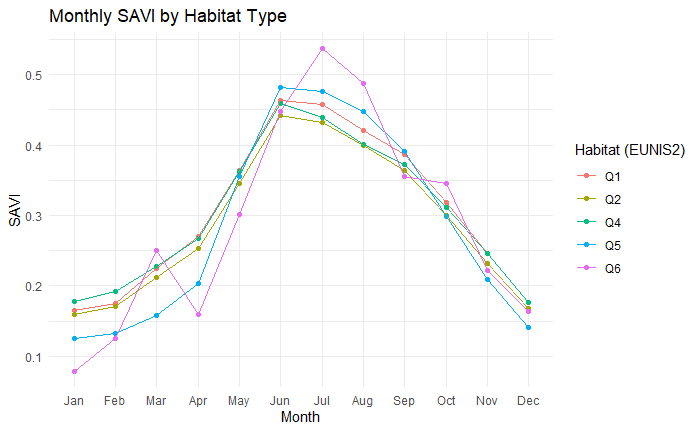

```r
# SAVI
ggplot(data_monthly_EUNIS2 %>%
         dplyr::filter(EUNIS1 == "Q" & !is.na(EUNIS2)) %>%
         # Remove those with EUNIS level 2 that does not match current classif
         dplyr::filter(EUNIS2 != "Qa" & EUNIS2 != "Qb"),
       aes(x = month, y = mean_SAVI, color = EUNIS2, group = EUNIS2)) +
  geom_point() +
  geom_line() +
  #geom(aes(ymin = mean_SAVI - sd_SAVI, ymax = mean_SAVI + sd_SAVI),
                #width = 0.2) +
  labs(
    title = "Monthly SAVI by Habitat Type",
    x = "Month",
    y = "SAVI",
    color = "Habitat (EUNIS2)"
  ) +
  theme_minimal()
ggsave(
  here("output", "figures", "monthly_spectrophenology_S2", "EUNIS2_Q_SAVI.jpeg"),
  dpi = 300, width = 7, height = 2.5)
```

### R

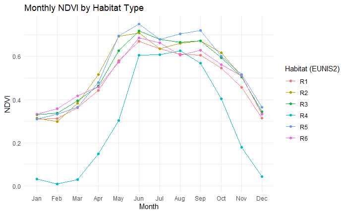

```r
ggplot(data_monthly_EUNIS2 %>%
         dplyr::filter(EUNIS1 == "R" & !is.na(EUNIS2)),
       aes(x = month, y = mean_NDVI, color = EUNIS2, group = EUNIS2)) +
  geom_point() +
  geom_line() +
  #geom(aes(ymin = mean_NDVI - sd_NDVI, ymax = mean_NDVI + sd_NDVI),
                #width = 0.2) +
  labs(
    title = "Monthly NDVI by Habitat Type",
    x = "Month",
    y = "NDVI",
    color = "Habitat (EUNIS2)"
  ) +
  theme_minimal()
ggsave(
  here("output", "figures", "monthly_spectrophenology_S2", "EUNIS2_R_NDVI.jpeg"),
  dpi = 300, width = 7, height = 2.5)
```

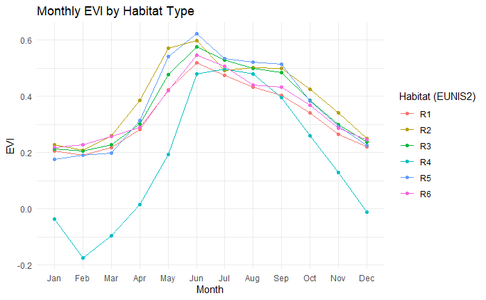

```r
ggplot(data_monthly_EUNIS2 %>%
         dplyr::filter(EUNIS1 == "R" & !is.na(EUNIS2)),
       aes(x = month, y = mean_EVI, color = EUNIS2, group = EUNIS2)) +
  geom_point() +
  geom_line() +
  #geom(aes(ymin = mean_EVI - sd_EVI, ymax = mean_EVI + sd_EVI),
                #width = 0.2) +
  labs(
    title = "Monthly EVI by Habitat Type",
    x = "Month",
    y = "EVI",
    color = "Habitat (EUNIS2)"
  ) +
  theme_minimal()
ggsave(
  here("output", "figures", "monthly_spectrophenology_S2", "EUNIS2_R_EVI.jpeg"),
  dpi = 300, width = 7, height = 2.5)
```

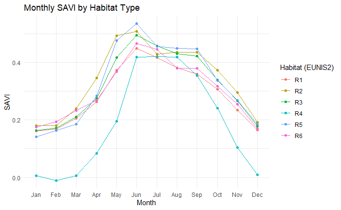

```r
ggplot(data_monthly_EUNIS2 %>%
         dplyr::filter(EUNIS1 == "R" & !is.na(EUNIS2)),
       aes(x = month, y = mean_SAVI, color = EUNIS2, group = EUNIS2)) +
  geom_point() +
  geom_line() +
  #geom(aes(ymin = mean_SAVI - sd_SAVI, ymax = mean_SAVI + sd_SAVI),
                #width = 0.2) +
  labs(
    title = "Monthly SAVI by Habitat Type",
    x = "Month",
    y = "SAVI",
    color = "Habitat (EUNIS2)"
  ) +
  theme_minimal()
ggsave(
  here("output", "figures", "monthly_spectrophenology_S2", "EUNIS2_R_SAVI.jpeg"),
  dpi = 300, width = 7, height = 2.5)
```

### S

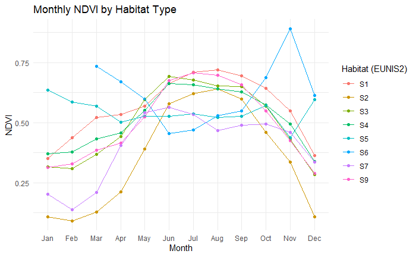

```r
ggplot(data_monthly_EUNIS2 %>%
         dplyr::filter(EUNIS1 == "S" & !is.na(EUNIS2)) %>%
         # Remove those with EUNIS level 2 that does not match current classif
         dplyr::filter(EUNIS2 != "Sa" & EUNIS2 != "Sb"),
       aes(x = month, y = mean_NDVI, color = EUNIS2, group = EUNIS2)) +
  geom_point() +
  geom_line() +
  #geom(aes(ymin = mean_NDVI - sd_NDVI, ymax = mean_NDVI + sd_NDVI),
                #width = 0.2) +
  labs(
    title = "Monthly NDVI by Habitat Type",
    x = "Month",
    y = "NDVI",
    color = "Habitat (EUNIS2)"
  ) +
  theme_minimal()
ggsave(
  here("output", "figures", "monthly_spectrophenology_S2", "EUNIS2_S_NDVI.jpeg"),
  dpi = 300, width = 8, height = 2.5)
```

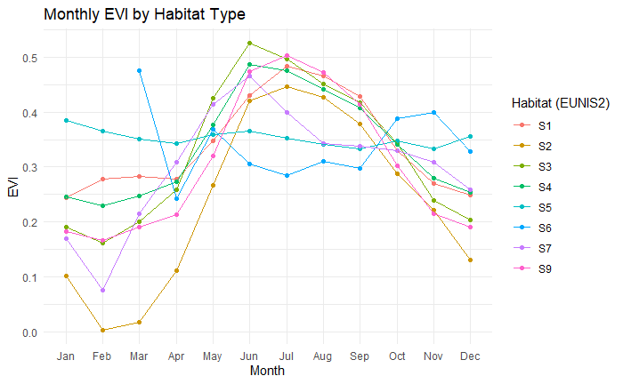

```r
ggplot(data_monthly_EUNIS2 %>%
         dplyr::filter(EUNIS1 == "S" & !is.na(EUNIS2)) %>%
         # Remove those with EUNIS level 2 that does not match current classif
         dplyr::filter(EUNIS2 != "Sa" & EUNIS2 != "Sb"),
       aes(x = month, y = mean_EVI, color = EUNIS2, group = EUNIS2)) +
  geom_point() +
  geom_line() +
  #geom(aes(ymin = mean_EVI - sd_EVI, ymax = mean_EVI + sd_EVI),
                #width = 0.2) +
  labs(
    title = "Monthly EVI by Habitat Type",
    x = "Month",
    y = "EVI",
    color = "Habitat (EUNIS2)"
  ) +
  theme_minimal()
ggsave(
  here("output", "figures", "monthly_spectrophenology_S2", "EUNIS2_S_EVI.jpeg"),
  dpi = 300, width = 8, height = 2.5)
```

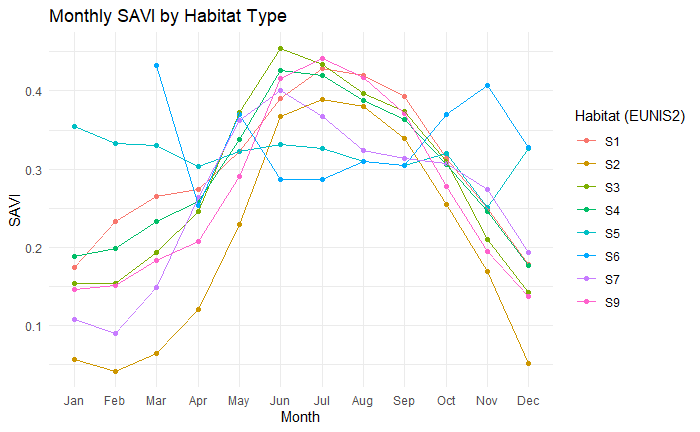

```r
ggplot(data_monthly_EUNIS2 %>%
         dplyr::filter(EUNIS1 == "S" & !is.na(EUNIS2)) %>%
         # Remove those with EUNIS level 2 that does not match current classif
         dplyr::filter(EUNIS2 != "Sa" & EUNIS2 != "Sb"),
       aes(x = month, y = mean_SAVI, color = EUNIS2, group = EUNIS2)) +
  geom_point() +
  geom_line() +
  #geom(aes(ymin = mean_SAVI - sd_SAVI, ymax = mean_SAVI + sd_SAVI),
                #width = 0.2) +
  labs(
    title = "Monthly SAVI by Habitat Type",
    x = "Month",
    y = "SAVI",
    color = "Habitat (EUNIS2)"
  ) +
  theme_minimal()
ggsave(
  here("output", "figures", "monthly_spectrophenology_S2", "EUNIS2_S_SAVI.jpeg"),
  dpi = 300, width = 8, height = 2.5)
```

### T

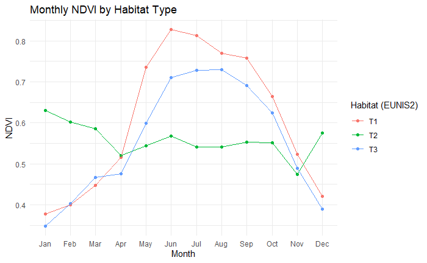

```r
ggplot(data_monthly_EUNIS2 %>%
         dplyr::filter(EUNIS1 == "T" & !is.na(EUNIS2)),
       aes(x = month, y = mean_NDVI, color = EUNIS2, group = EUNIS2)) +
  geom_point() +
  geom_line() +
  #geom(aes(ymin = mean_NDVI - sd_NDVI, ymax = mean_NDVI + sd_NDVI),
                #width = 0.2) +
  labs(
    title = "Monthly NDVI by Habitat Type",
    x = "Month",
    y = "NDVI",
    color = "Habitat (EUNIS2)"
  ) +
  theme_minimal()
ggsave(
  here("output", "figures", "monthly_spectrophenology_S2", "EUNIS2_T_NDVI.jpeg"),
  dpi = 300, width = 6, height = 2.5)
```

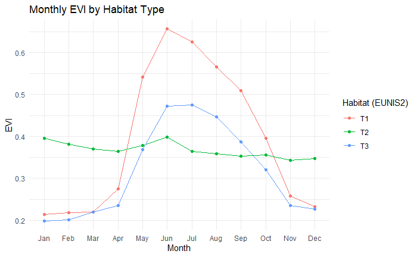

```r
ggplot(data_monthly_EUNIS2 %>%
         dplyr::filter(EUNIS1 == "T" & !is.na(EUNIS2)),
       aes(x = month, y = mean_EVI, color = EUNIS2, group = EUNIS2)) +
  geom_point() +
  geom_line() +
  #geom(aes(ymin = mean_EVI - sd_EVI, ymax = mean_EVI + sd_EVI),
                #width = 0.2) +
  labs(
    title = "Monthly EVI by Habitat Type",
    x = "Month",
    y = "EVI",
    color = "Habitat (EUNIS2)"
  ) +
  theme_minimal()
ggsave(
  here("output", "figures", "monthly_spectrophenology_S2", "EUNIS2_T_EVI.jpeg"),
  dpi = 300, width = 6, height = 2.5)
```

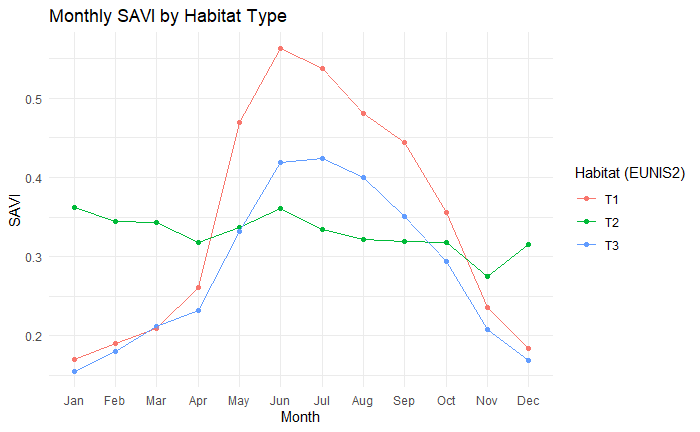

```r
ggplot(data_monthly_EUNIS2 %>%
         dplyr::filter(EUNIS1 == "T" & !is.na(EUNIS2)),
       aes(x = month, y = mean_SAVI, color = EUNIS2, group = EUNIS2)) +
  geom_point() +
  geom_line() +
  #geom(aes(ymin = mean_SAVI - sd_SAVI, ymax = mean_SAVI + sd_SAVI),
                #width = 0.2) +
  labs(
    title = "Monthly SAVI by Habitat Type",
    x = "Month",
    y = "SAVI",
    color = "Habitat (EUNIS2)"
  ) +
  theme_minimal()
ggsave(
  here("output", "figures", "monthly_spectrophenology_S2", "EUNIS2_T_SAVI.jpeg"),
  dpi = 300, width = 6, height = 2.5)
```

# Calculate other phenological metrics

```r
final_RS_data <- final_RS_data %>%
  mutate(
    # With slope method
    # Growing season duration
    NDVI_gsd = NDVI_eos_doy - NDVI_sos_doy,
    EVI_gsd = NDVI_eos_doy - NDVI_sos_doy,
    SAVI_gsd = SAVI_eos_doy - SAVI_sos_doy,
    # Difference in value between pos and sos
    NDVI_diff_pos_sos_value = NDVI_pos_value - NDVI_sos_value,
    EVI_diff_pos_sos_value = EVI_pos_value - EVI_sos_value,
    SAVI_diff_pos_sos_value = SAVI_pos_value - SAVI_sos_value,
    # Difference in value between pos and eos
    NDVI_diff_pos_eos_value = NDVI_pos_value - NDVI_eos_value,
    EVI_diff_pos_eos_value = EVI_pos_value - EVI_eos_value,
    SAVI_diff_pos_eos_value = SAVI_pos_value - SAVI_eos_value,
    # Difference in doy between pos and sos
    NDVI_diff_pos_sos_doy = NDVI_pos_doy - NDVI_sos_doy,
    EVI_diff_pos_sos_doy = EVI_pos_doy - EVI_sos_doy,
    SAVI_diff_pos_sos_doy = SAVI_pos_doy - SAVI_sos_doy,
    # Absolute difference in doy between pos and eos
    NDVI_diff_pos_eos_doy = abs(NDVI_pos_doy - NDVI_eos_doy),
    EVI_diff_pos_eos_doy = abs(EVI_pos_doy - EVI_eos_doy),
    SAVI_diff_pos_eos_doy = abs(SAVI_pos_doy - SAVI_eos_doy),
    # With months method
    # Difference in value between pos and march
    NDVI_diff_pos_march_value = NDVI_pos_value - NDVI_avg_value_03,
    EVI_diff_pos_march_value = EVI_pos_value - EVI_avg_value_03,
    SAVI_diff_pos_march_value = SAVI_pos_value - SAVI_avg_value_03,
    # Difference in value between pos and oct
    NDVI_diff_pos_oct_value = NDVI_pos_value - NDVI_avg_value_10,
    EVI_diff_pos_oct_value = EVI_pos_value - EVI_avg_value_10,
    SAVI_diff_pos_oct_value = SAVI_pos_value - SAVI_avg_value_10,
    # Difference in doy between pos and march
    NDVI_diff_pos_march_doy = NDVI_pos_doy - 75,
    EVI_diff_pos_march_doy = EVI_pos_doy - 75,
    SAVI_diff_pos_march_doy = SAVI_pos_doy - 75,
    # Difference in doy between pos and oct
    NDVI_diff_pos_oct_doy = abs(NDVI_pos_doy - 285),
    EVI_diff_pos_oct_doy = abs(EVI_pos_doy - 285),
    SAVI_diff_pos_oct_doy = abs(SAVI_pos_doy - 285),
    # With POS-2 and POS+2 method
    # Difference in value between pos and pos_minus60
    NDVI_diff_pos_minus60_value = NDVI_pos_value - NDVI_pos_minus60_value,
    EVI_diff_pos_minus60_value = EVI_pos_value - EVI_pos_minus60_value,
    SAVI_diff_pos_minus60_value = SAVI_pos_value - SAVI_pos_minus60_value,
    # Difference in value between pos and pos_plus60
    NDVI_diff_pos_plus60_value = NDVI_pos_value - NDVI_pos_plus60_value,
    EVI_diff_pos_plus60_value = EVI_pos_value - EVI_pos_plus60_value,
    SAVI_diff_pos_plus60_value = SAVI_pos_value - SAVI_pos_plus60_value
  )
```

## Checks

### Slope method

```r
# Growing season duration should be positive
nrow(final_RS_data %>%
       dplyr::filter(NDVI_gsd <= 0 | EVI_gsd <= 0 |
                       SAVI_gsd <= 0))
```

```
[1] 0
```

```r
# Difference in value between pos and sos should be positive
nrow(final_RS_data %>%
       dplyr::filter(NDVI_diff_pos_sos_value <= 0))
```

```
[1] 86
```

```r
nrow(final_RS_data %>%
       dplyr::filter(EVI_diff_pos_sos_value <= 0))
```

```
[1] 51
```

```r
nrow(final_RS_data %>%
       dplyr::filter(SAVI_diff_pos_sos_value <= 0))
```

```
[1] 36
```

```r
# Difference in value between pos and eos should be positive
nrow(final_RS_data %>%
       dplyr::filter(NDVI_diff_pos_eos_value <= 0))
```

```
[1] 276
```

```r
nrow(final_RS_data %>%
       dplyr::filter(EVI_diff_pos_eos_value <= 0))
```

```
[1] 237
```

```r
nrow(final_RS_data %>%
       dplyr::filter(SAVI_diff_pos_eos_value <= 0))
```

```
[1] 123
```

```r
# Difference in doy between pos and sos should be positive
nrow(final_RS_data %>%
       dplyr::filter(NDVI_diff_pos_sos_doy <= 0 |
                       EVI_diff_pos_sos_doy <= 0 |
                       SAVI_diff_pos_sos_doy <= 0))
```

```
[1] 0
```

```r
# Difference in doy between eos and pos should be positive
nrow(final_RS_data %>%
       dplyr::filter(NDVI_diff_pos_eos_doy <= 0 |
                       EVI_diff_pos_eos_doy <= 0 |
                       SAVI_diff_pos_eos_doy <= 0))
```

```
[1] 0
```

### POS-2 and POS+2 method

```r
# Difference in value between pos and pos_minus60 should be positive
nrow(final_RS_data %>%
       dplyr::filter(NDVI_diff_pos_minus60_value <= 0))
```

```
[1] 716
```

```r
nrow(final_RS_data %>%
       dplyr::filter(EVI_diff_pos_minus60_value <= 0))
```

```
[1] 602
```

```r
nrow(final_RS_data %>%
       dplyr::filter(SAVI_diff_pos_minus60_value <= 0))
```

```
[1] 704
```

```r
# Difference in value between pos and pos_plus60 should be positive
nrow(final_RS_data %>%
       dplyr::filter(NDVI_diff_pos_plus60_value <= 0))
```

```
[1] 291
```

```r
nrow(final_RS_data %>%
       dplyr::filter(EVI_diff_pos_plus60_value <= 0))
```

```
[1] 252
```

```r
nrow(final_RS_data %>%
       dplyr::filter(SAVI_diff_pos_plus60_value <= 0))
```

```
[1] 129
```

## Further checks (EVI)

### Slope method

```r
# Difference in value between pos and sos should be positive
nrow(final_RS_data %>%
       dplyr::filter(EVI_diff_pos_sos_value <= 0))
```

```
[1] 51
```

```r
# Difference in value between pos and eos should be positive
nrow(final_RS_data %>%
       dplyr::filter(EVI_diff_pos_eos_value <= 0))
```

```
[1] 237
```

# Add some columns needed

```r
final_RS_data <- final_RS_data %>%
  left_join(
    data_RS_S2_bands_indices %>%
      distinct(PlotObservationID, year, biogeo, unit)
    )
```

# Add canopy height data

Read the data:

```r
data_RS_CH <- read_csv(
  "C:/Data/MOTIVATE/MOTIVATE_RS_data/validation/Canopy_Height_1m/CanopyHeight_1m.csv")
```

Join:

```r
final_RS_data <- final_RS_data %>%
  left_join(data_RS_CH %>%
              dplyr::select(PltObID, canopy_height) %>%
              mutate(PltObID = factor(PltObID)) %>%
              rename(PlotObservationID = PltObID))
```

# Save to clean data

```r
write_tsv(final_RS_data,
          here("data", "clean","final_RS_data_bands_S2_all_20260310.csv"))
```